# FigureYa309cell2location

小丫画图出品

2023-3-24

欢迎关注“小丫画图”公众号，回复“小白”，看小视频，实现点鼠标跑代码。

小丫微信: epigenomics E-mail: figureya@126.com

作者：Jarning，他的更多作品看这里https://k.koudai.com/BXEtOldY

小丫编辑校验

# 需求描述

我想利用cell2location实现单细胞解析空间转录组中细胞的比例。 这个跟MIA不同，能够计算出每个空间位点中细胞亚型的比例，从而看各个细胞在空间中的交互作用。

FigureYa239ST_PDAChttps://k.youshop10.com/7Ols6b7-用的是MIA，它只能计算细胞在这个区域的可能性。 它用的数据是比较老的，一个样本只有几百个点。 现在空转的数据都是几千个点，精度远高于它，所以这种方式已经不适用了。

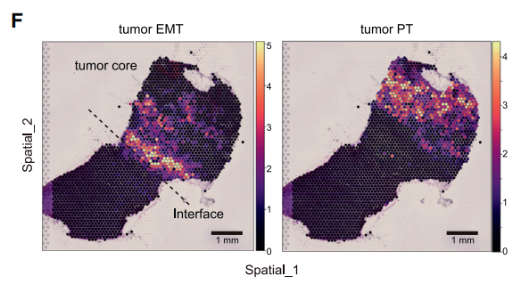

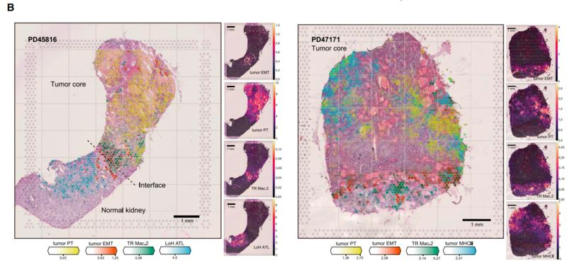

Figure 7. Cellular interactions in the ccRCC microenvironment (B) Spatial mapping of EMT tumor cells, PT tumor cells, and TR Mac.2 in Visium data for representative tumor-normal interface (PD45816) and tumor core (PD47171) samples using cell2location. Estimated abundance for cell types (color intensity) across locations (dots) is overlaid on histology images. Scale bars, 1 mm.

出自https://linkinghub.elsevier.com/retrieve/pii/S1535610822005487

# 应用场景

用cell2location实现单细胞解析空间转录组中细胞的比例，这里复现了例文的Figure 6F，S5D，7B。

以后众筹更多空间转录组的美图，都放在这里https://k.youshop10.com/vpaiQGgf

# 环境设置

下载并安装Anaconda发行版，https://www.anaconda.com/distribution/#download-section

里面已经包含了运行本文档所需的Python3、ipython、Jupyter notebook。

打开Anaconda——点击Jupyter notebook——选择`01_explore_space_transcriptome.ipynb`打开，在Jupyter Notebook中点击Run按钮，即可运行python代码。

## cell2location的安装

参考：https://github.com/BayraktarLab/cell2location#Installation

在终端Terminal运行以下命令

```bash
conda create -y -n cell2loc_env python=3.9
conda activate cell2loc_env
pip install cell2location[tutorials]
```

将该环境注入jupyter notebook

```bash
conda activate cell2loc_env
conda install ipykernel --yes
python -m ipykernel install --user --name=cell2loc_env --display-name='Environment (cell2loc_env)'
# OR
conda install nb_conda
```

# 输入文件

从Mendeley Data下载例文的输入文件：https://data.mendeley.com/datasets/g67bkbnhhg/1

01_explore_space_transcriptome.ipynb

# 分析

02_cell2location_signature.ipynb

03_cell2location_mapping.ipynb

# 画图 - Figure 6F，S5D，7B

04_cell2location_plot.ipynb